# Drug

Zhe Zhao(433707)

2022/5/26

```r
library(class)
library(dplyr)
library(readr)
```

```r
library(ggplot2)
library(caret)
library(verification)
library(corrplot)
library(gmodels)
library(kernlab)
library(tidyverse)
```

## Introduction

The main target of this project is using classification method of machine learning, to build a model explaining whether a particular person consumed cocaine in the last month based on the training sample and generate predictions for all observations from the test sample.

## Import data

Import data and check detailed information.

```r
## Read data
drug <- read.csv("C:/Users/zhaoz/Desktop/jiqixuexi/pro/drugs_train.csv")

## get a quick peek at the data
head(drug)
```

```
##           id   age gender                                            education
## 1 train_0001 45-54   male                                       Masters degree
## 2 train_0002 25-34   male                                    University degree
## 3 train_0003 18-24 female                                    University degree
## 4 train_0004 25-34 female                                       Masters degree
## 5 train_0005 18-24   male Some college or university, no certificate or degree
## 6 train_0006 18-24 female                              Left school at 18 years
##     country         ethnicity personality_neuroticism personality_extraversion
## 1       USA Mixed-Black/Asian                    57.6                     57.3
## 2       USA Mixed-Black/Asian                    47.8                     67.0
## 3       USA Mixed-Black/Asian                    57.6                     43.3
## 4       USA Mixed-Black/Asian                    71.8                     31.2
## 5 Australia Mixed-Black/Asian                    56.1                     62.3
## 6 Australia Mixed-White/Black                    47.8                     20.7
##   personality_openness personality_agreeableness personality_conscientiousness
```

[output cut: 34 more lines]

```r
## get dataset detailed infomation
str(drug)
```

```
## 'data.frame':    1500 obs. of  21 variables:
##  $ id                            : chr  "train_0001" "train_0002" "train_0003" "train_0004" ...
##  $ age                           : chr  "45-54" "25-34" "18-24" "25-34" ...
##  $ gender                        : chr  "male" "male" "female" "female" ...
##  $ education                     : chr  "Masters degree" "University degree" "University degree" "Masters degree" ...
##  $ country                       : chr  "USA" "USA" "USA" "USA" ...
##  $ ethnicity                     : chr  "Mixed-Black/Asian" "Mixed-Black/Asian" "Mixed-Black/Asian" "Mixed-Black/Asian" ...
##  $ personality_neuroticism       : num  57.6 47.8 57.6 71.8 56.1 47.8 75.2 53.4 60.8 30.1 ...
##  $ personality_extraversion      : num  57.3 67 43.3 31.2 62.3 20.7 69.6 54.9 72.2 93.7 ...
##  $ personality_openness          : num  50.1 45.7 55.3 43.6 70.2 57.8 62.5 27.8 62.5 64.7 ...
##  $ personality_agreeableness     : num  47.8 47.8 45.6 56.3 66.1 41.2 54.2 70.9 51.9 82.2 ...
##  $ personality_conscientiousness : num  53.7 56 49.9 31.8 42.4 33.6 38.7 66.4 63.6 53.7 ...
##  $ personality_impulsiveness     : num  42.8 33.8 63 63 50.4 56.5 56.5 21.5 50.4 56.5 ...
##  $ personality_sensation         : num  22.4 30.8 62 71.1 62 62 22.4 38.8 100 100 ...
##  $ consumption_alcohol           : chr  "used in last week" "used in last week" "used in last month" "used in last day" ...
##  $ consumption_amphetamines      : chr  "used over a decade ago" "never used" "never used" "never used" ...
##  $ consumption_caffeine          : chr  "used in last day" "used in last week" "used in last day" "used in last day" ...
##  $ consumption_cannabis          : chr  "used in last week" "never used" "used in last week" "used in last decade" ...
##  $ consumption_chocolate         : chr  "used in last day" "used in last day" "used in last week" "used in last day" ...
##  $ consumption_mushrooms         : chr  "never used" "never used" "used in last year" "never used" ...
##  $ consumption_nicotine          : chr  "used in last week" "never used" "used in last month" "used in last decade" ...
##  $ consumption_cocaine_last_month: chr  "No" "No" "No" "No" ...
```

## Divide data

Divide the data into training sample as 70% and testing sample as 30%.

```r
set.seed(123456)
# divide the data into training and testing sample
drug_which_training <- createDataPartition(drug$consumption_cocaine_last_month,
                                            p = 0.7,
                                            list = FALSE)

drug_train <-drug[c(drug_which_training),]
drug_test <- drug[-c(drug_which_training),]
## save data
save(list = c("drug_train",
              "drug_test"),
     file = "C:/Users/zhaoz/Desktop/jiqixuexi/pro/drug_train_test.RData")
```

I chose below variables: “age”, “gender”, “country”, “ethnicity”, “consumption_alcohol”,“consumption_amphetamines”,“consumption_cannabis”,“consumption_mushrooms”,“consumption_nicotine”, “consumption_cocaine_last_month”,“personality_neuroticism”, “personality_agreeableness”,“personality_conscientiousness”, “personality_impulsiveness”, “personality_sensation”

## Creat new dataset

Creat a new dataframe with selected variables.

```r
load("C:/Users/zhaoz/Desktop/jiqixuexi/pro/drug_train_test.RData")
drug_train_pro <- drug_train[,c("age", "gender", "country", "ethnicity", "consumption_alcohol",
                              "consumption_amphetamines","consumption_cannabis",
                              "consumption_mushrooms","consumption_nicotine", "consumption_cocaine_last_month",
                              "personality_neuroticism", "personality_agreeableness",
                              "personality_conscientiousness", "personality_impulsiveness", "personality_sensation")]
```

And for testing sample.

```r
drug_test <- drug_test[,c("age", "gender", "country", "ethnicity", "consumption_alcohol",
                              "consumption_amphetamines","consumption_cannabis",
                              "consumption_mushrooms","consumption_nicotine", "consumption_cocaine_last_month",
                              "personality_neuroticism", "personality_agreeableness",
                              "personality_conscientiousness", "personality_impulsiveness", "personality_sensation")]
```

## KNN Model

Why not Decision Tree? Need more time than KNN, but lower(just a little bit) accuracy! Why not SVM? Really long time taken, although there are only 1.5 thousand pieces of data.

Set “k”s

```r
## set “k”s
different_k <- data.frame(k = seq(1, 99, 4))
```

Check which value of k gives the highest AUC.

```r
ctrl_cv5a <- trainControl(method = "cv",
                          number = 5,
                          # probabilities of each level predicted in cross-validation
                          classProbs = TRUE,
                          # summary function that includes ROC
                          summaryFunction = twoClassSummary)
```

In the case of cross-validation, should apply transformations of input data in the train() function, I use preProcess = “range”. And I also use validation with probabilities and twoClassSummary.

```r
set.seed(2222)
drug_train_pro_knn_tuned_scaled2 <-
  train(consumption_cocaine_last_month ~ .,
        data = drug_train_pro,
        # knn
        method = "knn",
        # validation used - with probabilities and twoClassSummary
        trControl = ctrl_cv5a,
        # parameters to be compared
        tuneGrid = different_k,
        preProcess = c("range"),
        metric = "ROC")
```

[output not shown]

[output cut: 19 more lines]

[output not shown]

```r
drug_train_pro_knn_tuned_scaled2
```

```
## k-Nearest Neighbors
##
## 1051 samples
##   14 predictor
##    2 classes: 'No', 'Yes'
##
## Pre-processing: re-scaling to [0, 1] (53)
## Resampling: Cross-Validated (5 fold)
## Summary of sample sizes: 841, 841, 841, 840, 841
## Resampling results across tuning parameters:
##
##   k   ROC        Sens       Spec
##    1  0.5612582  0.9303595  0.19215686
##    5  0.6628637  0.9844182  0.02287582
##    9  0.6872715  0.9989637  0.01111111
```

[output cut: 25 more lines]

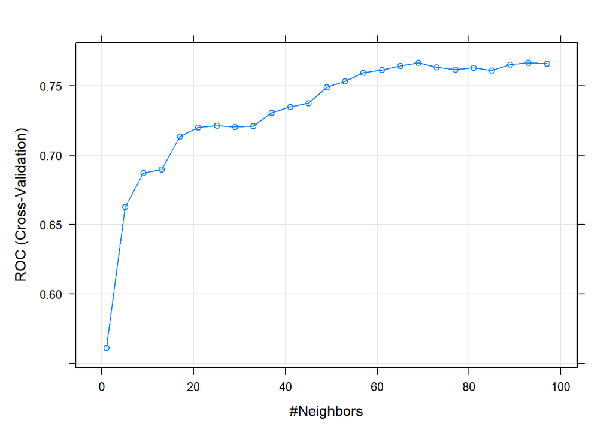

```r
plot(drug_train_pro_knn_tuned_scaled2)
```

Optimal k is 69.

Now run the model for testing sample and check. Testing sample is names “drug_test”, separated from “drug_train”.

```r
drug_test$predicted <- drug_train_pro_knn_tuned_scaled2 %>% predict(drug_test)
```

Lets built a confusion matrix table.

```r
# confusion matrix table
confusion_table = table(drug_test[,'predicted'], drug_test[,'consumption_cocaine_last_month'])
confusion_table
```

```
##
##        No Yes
##   No  411  38
##   Yes   0   0
```

Definite of TP,TN,FP,FN.

```r
## Definition of TP,TN,FP,FN
confusion_table[1,1] = 'TN'
confusion_table[1,2] = 'FN'
confusion_table[2,1] = 'FP'
confusion_table[2,2] = 'TP'
## output
confusion_table
```

```
##
##       No Yes
##   No  TN FN
##   Yes FP TP
```

Write a function to calculate accuracy.

```r
## function
et_accuracy <- function(df, predicted, actual){
  confusion_table = table(drug_test[,'predicted'], drug_test[,'consumption_cocaine_last_month'])
  TP = confusion_table[2,2]
  TN = confusion_table[1,1]
  FN = confusion_table[1,2]
  FP = confusion_table[2,1]
  accuracy = round((TP + TN) / sum(TP,FP,TN,FN), 2)
  return(accuracy)
}
```

Use this function to check the accuracy of testing sample!

```r
## accuracy value
score = data.frame(accuracy = et_accuracy(drug_test,'predicted','consumption_cocaine_last_month'))

## output
score
```

```
##   accuracy
## 1     0.92
```